# Assignment 2 Empirical Question (Propublica on COMPAS)

Lutfi Sun

2/15/2022

# Reading

### COMPAS

- What need does the software serve? What does the algorithm try to predict and what inputs do you think it uses?
  - When someone is accused of a crime, it takes time to gather evidence, set up a trial, and reach a final verdict. However, there are urgent decisions to make that cannot wait for the verdict or even the trial: whether the defendant should be detained, kept under custody, or allowed to go freely or at a price (bail bond).
  - A big reason behind limiting freedom before trial is the risk that the defendant might commit a crime again (called recidivism). And that is where risk assessment tools like COMPAS come in.
  - Using historical data, these softwares inform the officials about the likelihood of recidivism for a given defendant. COMPAS specifically turns these probability measures into a scale from one (lowest risk) to ten (highest risk) and reports this score to the user.
- What are type 1 and type 2 errors in this case?
  - Type 1 (False Positive): assigns a high risk score to an individual who would not actually reoffend / repeat a crime.
  - Type 2 (False Negative): assigns a low risk score to an individual who would actually reoffend / repeat a crime.
- What do you think are some advantages and disadvantages of using an algorithm in judicial decisions?
  - Advantages: less time spent on paper work, faster decision making, more information being utilized, more scrutiny and less discretion given to officials who might be biased…
  - Disadvantages: historical biases reintroduced into the system, less individualized investigations, reduced expertise, and more attention given to the algorithm predictions/scores instead of specifics of a case…
  - Examples:
    - As mentioned in this particular case, officials do not have much time to make pretrial decisions. A risk assessment algorithm can help condense the information of a given defendant and make use of historical data that the officials would otherwise not be familiar with. These tools, however, can exacerbate systemic biases. An example source of such bias in the training data can be that black recidivism was better recorded in the past than white recidivism.
    - It is very difficult for officials to be familiar with all the previous similar incidents and decisions. An algorithm can help them find such cases and show what laws apply. Although it makes the search and processing of information faster, a wide use of such an algorithm may lead to an exaggeration of similarities and a decrease in attention to specifics.

### ProPublica

- How does ProPublica assess the performance of COMPAS? How do they define accuracy?
  - The authors define accuracy as the risk categories correctly predicting actual recidivism within two years of the date the person was given a score. Example of a correct prediction: an individual given high risk score re-offends within two years.
  - They first check whether risk scores given to defendants can explain their recidivism and whether COMPAS does that better or worse depending on race and how the direction of its errors changes across racial lines.
  - They use a logistic regression model and a Cox model with race interactions.
  - The study concludes that the algorithm overpredicts African-American defendants’ future recidivism risk and underpredicts for Whites.
- What county does ProPublica focus on and why? Why does this county choose using Northpointe’s software?
  - Broward County, Florida. The county has strong open-records laws and has been using COMPAS extensively in pretrial decisions since 2008.
  - They started using the software to address overcrowding in the county jail system.
  - How does ProPublica access the data? Through a [public records request](https://www.propublica.org/article/how-we-analyzed-the-compas-recidivism-algorithm)
- Do you think there are any problems with ProPublica’s assessment?
  - It is impossible to have a good counterfactual in assessing the performance of such an algorithm. The score a person receives can have an indirect or direct effect on their behavior. For example, a person given a high score may not reoffend simply because they were given less freedom/chance to do so based on this score.
  - In their analysis, the authors exclude some observations without explanation even though date, scores, and other variables were available.
  - They collapse moderate risk and high risk into one category (high).
  - Not much discussion on the limitations of their methodology.
  - Nevertheless, the findings should ring alarm bells and increase scrutiny against the production and use of risk assessment tools.

# Empirical

```r
rm(list = ls()) # cleans the work environment (anything that was saved before)
library(knitr)
library(tidyverse)
```

Using the prop_compas_eco350k.csv file (in the data folder) answer the following:

**1. Which variables have missing values and why do you think they might be missing?**

```r
compas_raw <- read_csv("raw_data/prop_compas_eco350k.csv")
glimpse(compas_raw) # we see that the read_csv function automatically detects the types of each column. check ?read_csv to see how you can do it manually: will use col_types option
```

```
## Rows: 11,757
## Columns: 17
## $ id                    <dbl> 1, 2, 3, 4, 5, 6, 7, 8, 9, 10, 11, 12, 13, 14, 1…
## $ sex                   <chr> "Male", "Male", "Male", "Male", "Male", "Male", …
## $ dob                   <date> 1947-04-18, 1985-02-06, 1982-01-22, 1991-05-14,…
## $ race                  <chr> "Other", "Caucasian", "African-American", "Afric…
## $ c_offense_date        <date> 2013-08-13, NA, 2013-01-26, 2013-04-13, 2013-01…
## $ compas_screening_date <date> 2013-08-14, 2014-12-31, 2013-01-27, 2013-04-14,…
## $ decile_score          <dbl> 1, 5, 3, 4, 8, 1, 1, 6, 4, 1, 10, 5, 3, 4, 6, 1,…
## $ c_jail_in             <chr> "2013-08-13 6:03:42", NA, "2013-01-26 3:45:27", …
## $ c_jail_out            <chr> "2013-08-14 5:41:20", NA, "2013-02-05 5:36:53", …
## $ c_arrest_date         <date> NA, NA, NA, NA, NA, 2013-01-09, NA, NA, 2013-08…
## $ c_charge_degree       <chr> "F", "O", "F", "F", "F", "F", "M", "F", "F", "M"…
## $ c_charge_desc         <chr> "Aggravated Assault w/Firearm", NA, "Felony Batt…
## $ r_offense_date        <date> NA, NA, 2013-07-05, 2013-06-16, NA, NA, NA, 201…
## $ r_charge_degree       <chr> "O", "O", "F", "M", "O", "O", "O", "F", "O", "O"…
## $ r_charge_desc         <chr> NA, NA, "Felony Battery (Dom Strang)", "Driving …
## $ r_jail_in             <date> NA, NA, NA, 2013-06-16, NA, NA, NA, 2014-03-31,…
## $ r_jail_out            <date> NA, NA, NA, 2013-06-16, NA, NA, NA, 2014-04-18,…
```

```r
# A special type of variable in r is date. Even tho it is stored in the csv as yyyy-mm-dd, r will interpret it as number of days since 1970

compas_missing <- compas_raw %>%
  summarise_all(funs(sum(is.na(.))))  %>% # count the number of missing values for every column and save
  gather(variable, count_miss) %>% # transpose the matrix
  filter(count_miss != 0)  %>% # filtering out the variables with no missing values
  mutate(
    count_all = nrow(compas_raw), # add the total number of observations
    missing_percent = 100*count_miss / count_all # calculate percentage of observations with missing values
    )

kable(compas_missing) # a function from knitr package that prints tables nicely
```

| variable | count_miss | count_all | missing_percent |
| --- | --- | --- | --- |
| c_offense_date | 2600 | 11757 | 22.114485 |
| c_jail_in | 1180 | 11757 | 10.036574 |
| c_jail_out | 1180 | 11757 | 10.036574 |
| c_arrest_date | 9899 | 11757 | 84.196649 |
| c_charge_desc | 749 | 11757 | 6.370673 |
| r_offense_date | 8054 | 11757 | 68.503870 |
| r_charge_desc | 8114 | 11757 | 69.014204 |
| r_jail_in | 9297 | 11757 | 79.076295 |
| r_jail_out | 9297 | 11757 | 79.076295 |

Most of the time, real world data will not be very explanatory, and you will have to make sense: what does the variable name refer to, what does it mean for its value to be missing, how is it related to other variables… Let’s try to make sense of what we see now:

- offense_date: possibly law enforcement agents did not know the date of the offense (eg: a murder happened and body found, but date is unknown)
  - 22 percent of the time we do not know the offense date
- jail_in, jail_out: maybe the person did not spend time in jail
  - Then, 10 percent of the defendants were not detained
- c_arrest_date: possibly no arrest made
  - 84 percent was not arrested (for the initial offense)
- r_offense : the person did not re-offend
  - 69 percent did not re-offend
- r_jail : the person did not spend time in jail the second time. Note that this includes those who did not re-offend as well.
  - 79 - 69 = 10 percent of the individuals re-offended and was not detained after the second offense.

**2. Age on the date of offense**

Think about how you can find age using the data available and make an age variable. Can we guess age when offense date is unavailable? How?

```r
compas <- compas_raw %>% # I keep a copy of the raw dataset as compas_raw and will operate on compas from now on
  mutate(
    age = as.numeric( round( difftime(c_offense_date, dob)/365 ) )
    # get number of days between offense and date of birth. divide by 365. round. make it numerical (otherwise the difftime function will store and tell r to interpret it as number of days)
  )

sum(is.na(compas$age)) # we are missing age variable for 2600 observations. notice that we are missing offense date for 2600 observations as well.
```

```
## [1] 2600
```

```r
# one way we can go about this is to use other dates that are available in the data. see that the compas_screening_date was never missing for example

mean((compas$compas_screening_date- compas$c_offense_date), na.rm = TRUE) # on average the screening happened 47 days after the date of offense
```

```
## Time difference of 47.30949 days
```

```r
# let's use this info to guess age on the offense date

compas <- compas %>%
  mutate(
    age = ifelse(
      is.na(age), # if it's missing
      as.numeric(round( (difftime(compas_screening_date, dob)+45)/365 )), # assign our guess
      age) # otherwise (if it's not missing), keep it as is
    )
    # get number of days between offense and date of birth. divide by 365. round. make it numerical (otherwise the difftime function will store and tell r to interpret it as number of days)

sum(is.na(compas$age)) # we don't have any missing age anymore :)
```

```
## [1] 0
```

Make a histogram of age and comment on its distribution and outliers

```r
summary(compas$age) # youngest offender is 15 and oldest is 95 years old with 33 being the average age
```

```
##    Min. 1st Qu.  Median    Mean 3rd Qu.    Max.
##   15.00   24.00   30.00   33.24   41.00   95.00
```

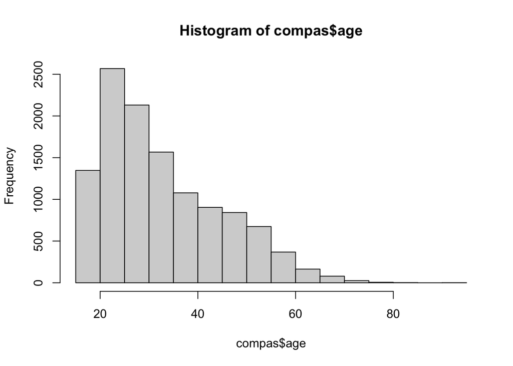

```r
hist(compas$age, breaks = 20)
```

- most offenders are around 20-35, and the distribution is right skewed => higher concentration of younger ppl

Discretize your age variable using bins of your choice and make a categorical variable

- I am choosing bins: below 21, 21-30, 31-40, 41-50, 50+

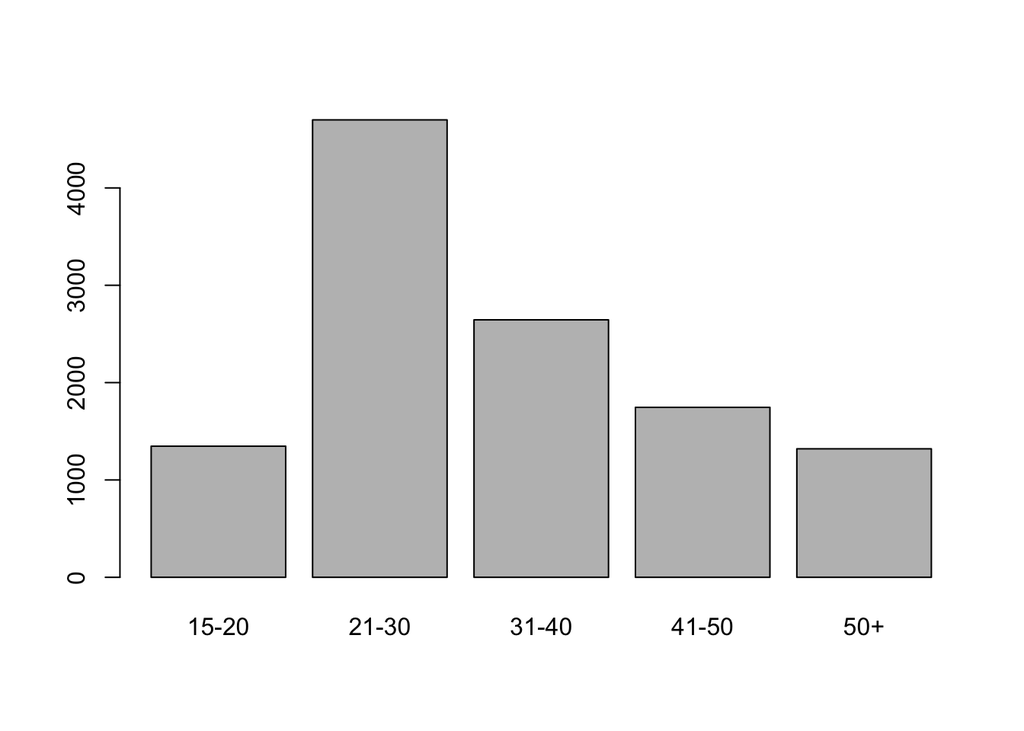

```r
compas <- compas %>%
  mutate(
    age_bin = "15-20",
    age_bin = replace(age_bin, age > 20 & age < 31, "21-30"),
    age_bin = replace(age_bin, age > 30 & age < 41, "31-40"),
    age_bin = replace(age_bin, age > 40 & age < 51, "41-50"),
    age_bin = replace(age_bin, age > 50, "50+")
  )
barplot(table(compas$age_bin)) # this is similar to how you'd draw a histogram for age, but here we are picking the bins. And since it's stored as categorical, it's called a barplot
```

**3. Distribution of decile scores**

```r
summary(compas$decile_score) # seems like there is a typo where some decile scores are entered as -1
```

```
##    Min. 1st Qu.  Median    Mean 3rd Qu.    Max.
##  -1.000   2.000   4.000   4.371   7.000  10.000
```

```r
sum(compas$decile_score == -1) # we have 15 such observations
```

```
## [1] 15
```

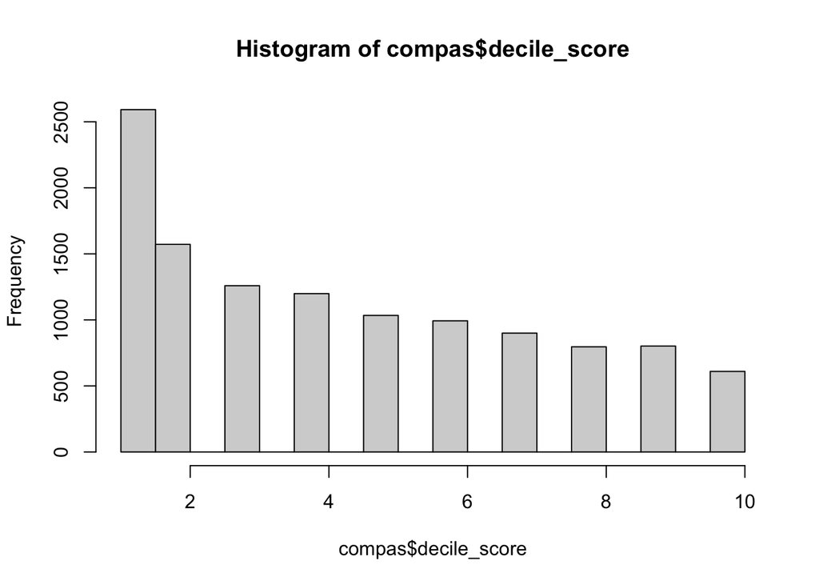

```r
# I will mark those observations as typo and assume they were supposed to be 1 instead of -1. marking because we can check later whether our conclusions depend on those questionable observations (whether they change anything)
compas <- compas %>%
  mutate(
    decile_typo = 0,
    decile_typo = replace(decile_typo, decile_score < 0, 1),
    decile_score = replace(decile_score, decile_score < 0, 1)
  )
hist(compas$decile_score, breaks = 20)
```

**4. Make a dummy variable (call it recid) which equals 1 if crime was repeated and zero if not.**

**5. Calculate average recidivism rate by gender and by race comment on findings**

```r
compas <- compas %>%
  mutate(
    recid = 0,
    recid = replace(recid, !is.na(r_offense_date), 1)
  )
summary(compas$recid)
```

```
##    Min. 1st Qu.  Median    Mean 3rd Qu.    Max.
##   0.000   0.000   0.000   0.315   1.000   1.000
```

```r
# let's first analyze by gender and age

compas_genage <- compas %>%
  group_by(sex, age_bin)  %>%
  summarise(recid = mean(recid))
```

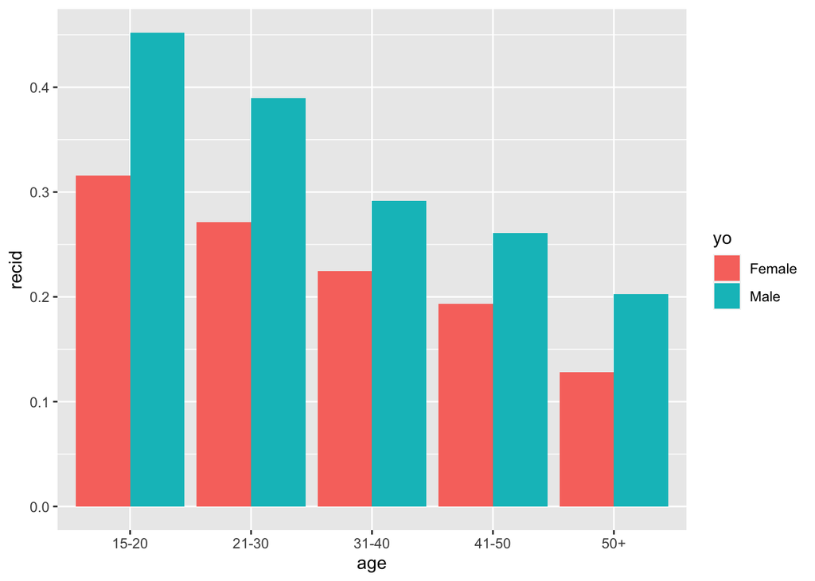

```r
compas_genage_graph  <- compas_genage  %>%
  ggplot( aes( x=age_bin, y=recid , fill=sex)) +
  geom_bar(stat="identity", position=position_dodge()) +
  xlab("age") + ylab("recid")+
  guides(fill = guide_legend(title = "yo"))

compas_genage_graph
```

```r
# now by gender and race

compas_genrace <- compas %>%
  group_by(sex, race)  %>%
  summarise(recid = mean(recid))
```

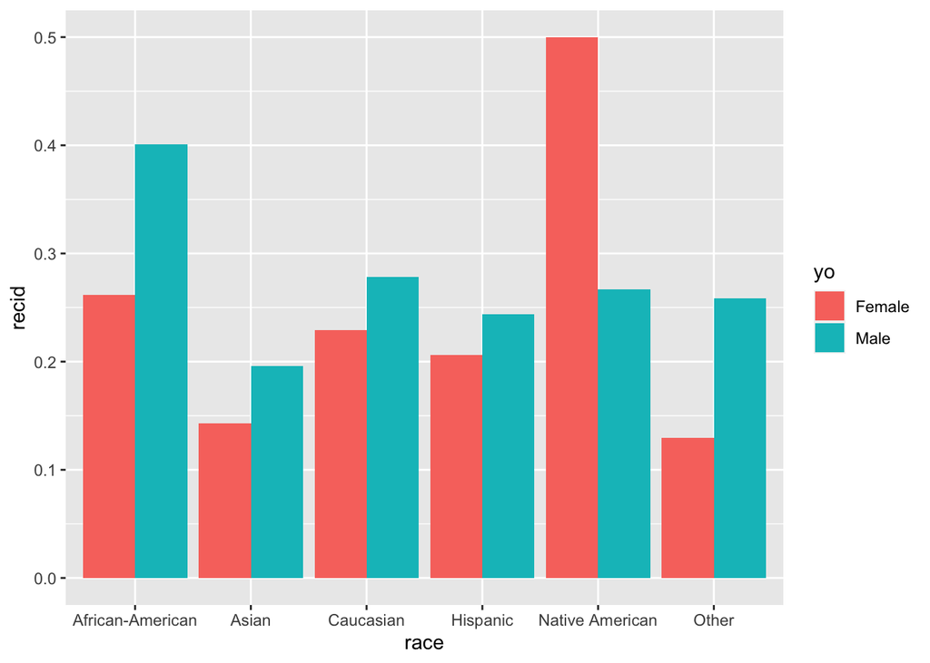

```r
compas_genrace_graph  <- compas_genrace  %>%
  ggplot( aes( x=race, y=recid , fill=sex)) +
  geom_bar(stat="identity", position=position_dodge()) +
  xlab("race") + ylab("recid")+
  guides(fill = guide_legend(title = "yo"))

compas_genrace_graph
```

```r
sum( (compas$sex == "Female") * (compas$race == "Native American") ) # only ten observations of native american females
```

```
## [1] 10
```

**6. Make a variable for time between first and repeated offense and make a histogram comment on distribution**

```r
compas <- compas %>%
  mutate(
    recid_time = difftime(r_offense_date, c_offense_date),
    recid_time = replace(recid_time, is.na(recid_time),
                        difftime(r_offense_date, compas_screening_date - 45))
  )
# as you'd remember there are some missing c_offense_date entries. So when you calculate the recid_time, those would be missing, but we can make an educated guess using the screening date.
summary(as.numeric(compas$recid_time))
```

[output not shown]

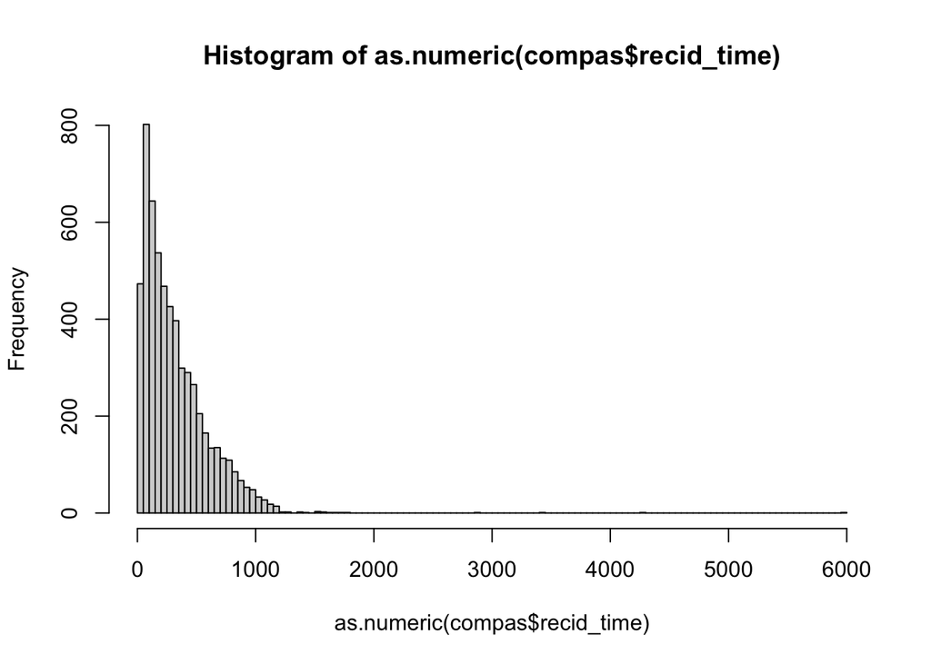

```r
hist(as.numeric(compas$recid_time), breaks = 100)
```